# Reproducible Research: Peer Assessment 1

# Coursera course on Reproducible Research

# Peer Assessment Project 1

## Loading and preprocessing the data

Load the data

```r
activity_data <- read.csv("activity.csv")
```

## What is the mean total number of steps taken per day?

Calculate the number of steps taken per day, then show the histogram of the number of steps taken per day

```r
library(plyr)
spd_data <- ddply(activity_data,c("date"),summarise, steps_per_day = sum(steps)) # using ddply
```

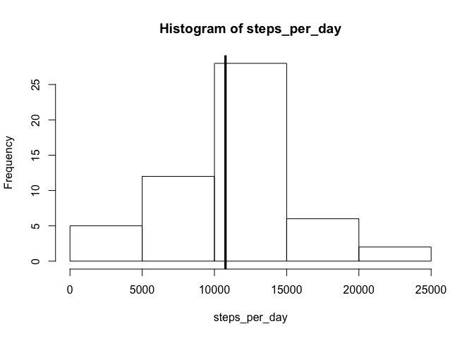

```r
mean_spd <- mean(spd_data$steps_per_day, na.rm = TRUE)
median_spd <- median(spd_data$steps_per_day, na.rm = TRUE)
with(spd_data, hist(steps_per_day))
abline(v = mean_spd, lwd = 3)
abline(v = median_spd, lwd = 3)
```

## What is the average daily activity pattern?

Make a time series plot (i.e. type = “l”) of the 5-minute interval (x-axis) and the average number of steps taken, averaged across all days (y-axis)

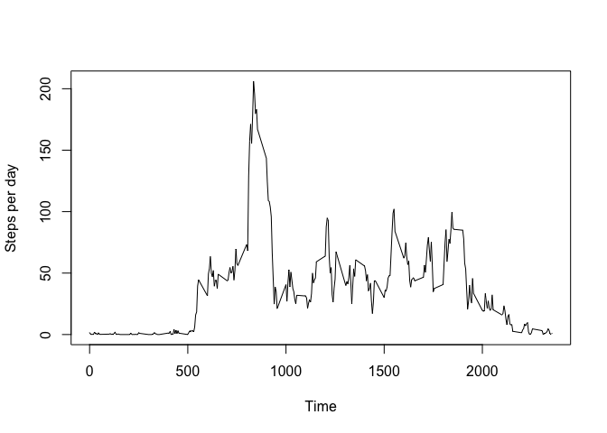

```r
interval_data <- ddply(activity_data,c("interval"),summarise, steps_per_interval = mean(steps, na.rm = TRUE)) # using ddply

with(interval_data,plot(unique(interval),steps_per_interval, type = "l",xlab = "Time", ylab = "Steps per day"))
```

```r
max_interval <- interval_data$interval[which.max(interval_data$steps_per_interval)]
```

## Imputing missing values

Compute missing data statistics

```r
total_missing_data = sum(is.na(activity_data$steps))
missing_data_pct = mean(is.na(activity_data$steps))
```

Imputing missing data using the mean of the 5 interval computed over the whole period

I’d like to avoid using a for loop for this, here how:

- Replicate the summarised interval data for the 61 days period, for a total of 61*288 = 17568
- Exploit the fact that both the original activity data and interval data are ordered
- Find the missing values, and replace the step column of activity data with the corresponding entry of the average interval data

```r
stretched_interval_data <- rep(interval_data$steps_per_interval, length(unique(activity_data$date)))
missing_step_data <- is.na(activity_data$steps)
new_activity_data <- activity_data
new_activity_data[missing_step_data,"steps"] <- stretched_interval_data[missing_step_data]
```

Show the histogram of the number of steps taken per day with the imputed data

```r
new_spd_data <- ddply(new_activity_data,c("date"),summarise, steps_per_day = sum(steps)) # using ddply
```

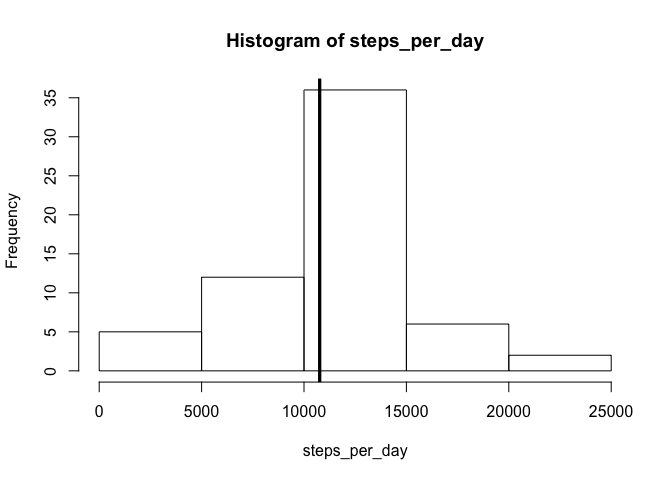

```r
new_mean_spd <- mean(new_spd_data$steps_per_day)
new_median_spd <- median(new_spd_data$steps_per_day)
with(new_spd_data, hist(steps_per_day))
abline(v = mean_spd, lwd = 3)
abline(v = median_spd, lwd = 3)
```

```r
mean_diff_pct = (mean_spd-new_mean_spd)/new_mean_spd*100
median_diff_pct = (median_spd-new_median_spd)/new_median_spd*100
```

## Are there differences in activity patterns between weekdays and weekends?

```
## geom_smooth: method="auto" and size of largest group is <1000, so using loess. Use 'method = x' to change the smoothing method.
## geom_smooth: method="auto" and size of largest group is <1000, so using loess. Use 'method = x' to change the smoothing method.
```

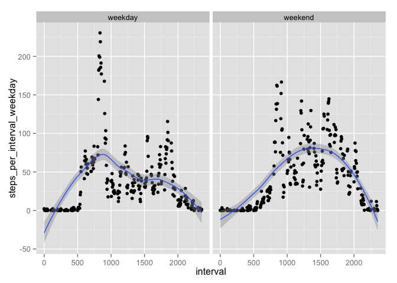

```r
new_activity_data$date = as.Date(new_activity_data$date, "%Y-%m-%d")
new_activity_data$weekday = as.factor(weekdays(new_activity_data$date))
new_activity_data$weekday <- revalue(new_activity_data$weekday, c("Monday"= "weekday","Tuesday"= "weekday",
                                                                  "Wednesday"= "weekday","Thursday"= "weekday",
                                                                  "Friday"= "weekday","Saturday"= "weekend",
                                                                  "Sunday"= "weekend"))
interval_data_weekday <- ddply(new_activity_data,c("weekday","interval"),summarise, steps_per_interval_weekday = mean(steps, na.rm = TRUE)) # using ddply
library(ggplot2)
g <- ggplot(interval_data_weekday, aes(interval,steps_per_interval_weekday))
g <- g + geom_point() + facet_grid(. ~ weekday) + geom_smooth()
print(g)
```